# Lecture 2: Digital Marketing and Advertising Psychology

SKOC42: Digital Marketing Communication 2026

nils.holmberg@iko.lu.se

## Lecture overview

1. `Defining Marketing Comm.`
   - What is it? Main types
   - What is it not?
2. `Advertising Psychology`
   - Awareness
   - Consideration
   - Conversion
3. `Digital Marketing`
   - Search / SEM
   - Display
   - Social media
4. `SOSTAC Framework`
   - Planning
   - Monitoring

## Section 01:

Defining Marketing  
Communication

## Marketing Communication

- `Marketing defined: Identifying, anticipating & satisfying customer requirements profitably`
- Facilitates the ‘exchange of value’ between manufacturers and consumers
- Strategic techniques for acquiring new customers (CRM)
- Develops long-term customer relationships
- Foundation for all digital marketing activity

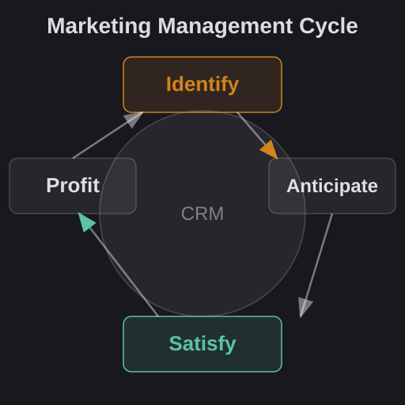

## B2C and B2B Models

- `Transaction types: B2C: organization sells directly to individual consumers`
- B2B: inter-organizational transactions between two or more businesses
- B2B involves complex buying units and longer decision cycles
- Different demand patterns: derived vs. direct consumer demand
- Communication strategies differ significantly between models

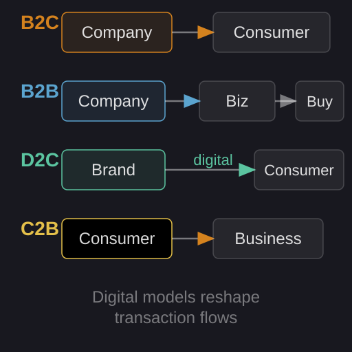

## D2C and C2B

- `Modern models: D2C: brands sell directly via digital media, bypassing intermediaries`
- C2B: consumers approach businesses with offers or feedback
- Both reflect digital transformation of business models
- D2C removes friction and shortens the path to purchase
- C2B examples: freelance platforms, user reviews, crowdsourcing

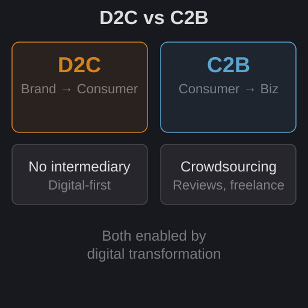

## C2C and User-Generated Content

- `Peer interactions: C2C: informational or financial exchanges between individuals`
- Mediated through third-party platforms (eBay, Airbnb, Reddit)
- UGC includes reviews, comments, and social media posts
- Peer recommendations are highly influential for new customers
- Brand communities amplify trust and word-of-mouth

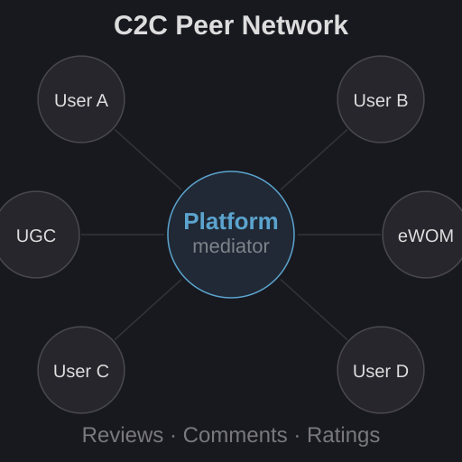

## The AIDA Model

- `Classic hierarchy: Attention: create brand awareness, cut through clutter`
- Interest: arouse curiosity about product attributes
- Desire: build affective preference and positive brand image
- Action: trigger purchase or trial behavior
- Assumes a linear ‘think–feel–do’ sequence

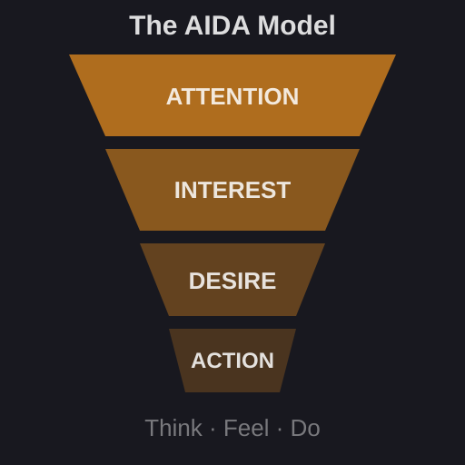

## AIDA Communication Objectives

- `Strategic alignment: Attention → Awareness objective: cut through advertising clutter`
- Interest/Desire → Persuasion: build preference and positive affect
- Action → Behavior: convert preference into purchase
- KPIs should map to each AIDA stage
- Different channels suit different stages of the model

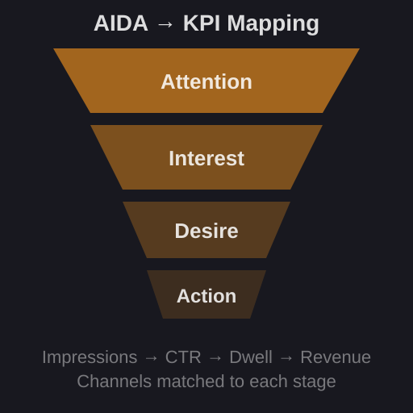

## Marketing vs. Branding

- `Key distinction: Marketing manages customer requirements and commercial returns`
- Branding distinguishes a product by sum of perceived characteristics
- Digital branding uses technology to create brand value
- Brand image, personality, and reflection are core branding goals
- Both disciplines operate together in integrated campaigns

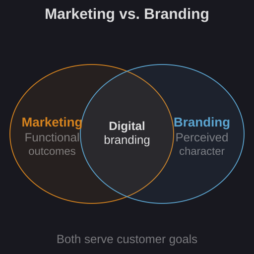

## Marketing vs. PR

- `Communication goals: Marketing focuses on facilitating competition and driving sales`
- PR manages awareness, understanding, and organizational reputation
- PR targets ‘publics’ rather than customers alone
- PR seen as ‘symmetrical’ but often fosters favorable evaluations
- Integrated strategies align both for consistent messaging

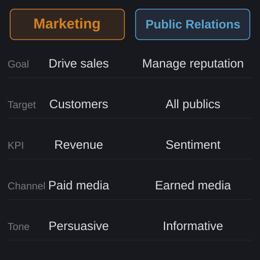

## Ethics in Marketing

- `Integrity vs. deception: Ethical marketing adheres to accepted moral standards`
- Misleading claims exploit pragmatic inferences — literally true, figuratively false
- The ‘truth effect’: repeated claims feel credible due to familiarity
- Regulators increasingly scrutinize digital advertising claims
- Transparency builds long-term brand trust

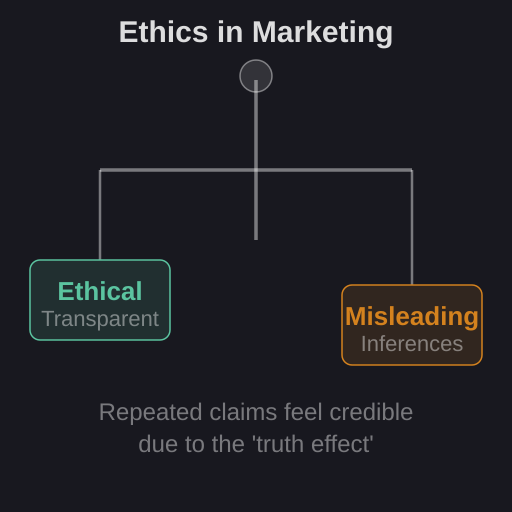

## Covert Persuasion

- `Hidden influence: Traditional marketing is an identified form of communication`
- Product placement: paid inclusion of brands in media content
- Native advertising matches editorial design to appear organic
- Influencer marketing blurs line between opinion and promotion
- Disclosure regulations aim to protect consumer autonomy

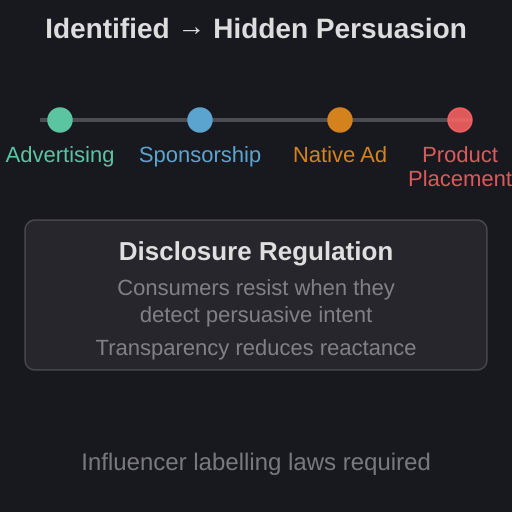

## Section 02:

Advertising  
Psychology

## Breaking Through Clutter

- `Attention: Attention: process by which a stimulus enters conscious awareness`
- Salience: contextual contrast makes an ad stand out
- Vividness: emotional interest sustains engagement
- Preattentive analysis: stimuli stored in implicit memory without focus
- Advertisers must compete with ever-increasing media noise

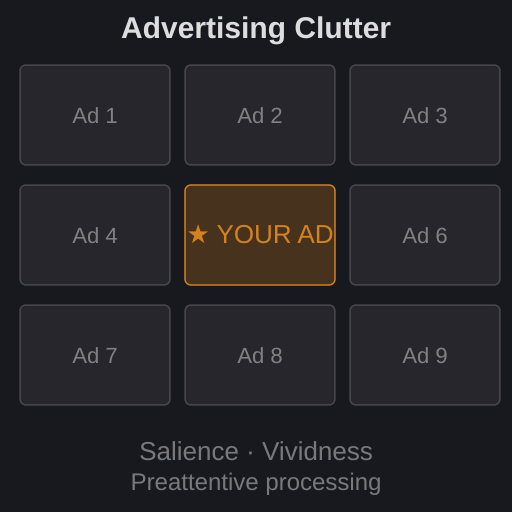

## Engaging the Consumer

- `Interest: Focal attention: stimulus is identified and categorized consciously`
- Arouses curiosity about product attributes and availability
- Simple, comprehensible messages reduce miscomprehension
- Historical miscomprehension rates of ads can exceed 30%
- Storytelling and relevance drive sustained interest

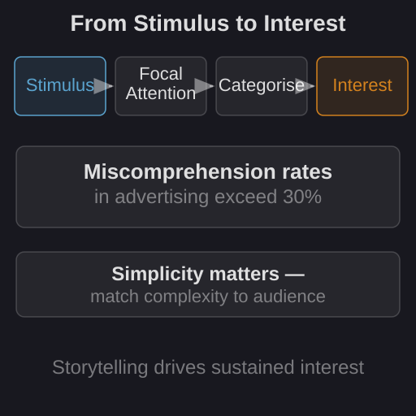

## Creating Brand Desire

- `Desire: Affective phase: thinking leads to emotional responses`
- Goal: create positive brand image by highlighting desirable attributes
- Evaluative conditioning transfers positive affect from context to brand
- Music, visuals, and endorsers shape emotional responses
- Brand preference formed before purchase decision

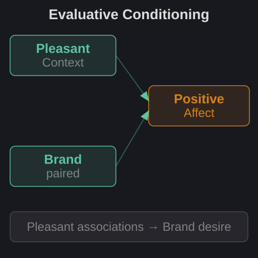

## Facilitating Purchase

- `Action: Conative/behavioral response: consumer purchases or tries the product`
- Purchase facilitation: ensuring ability and opportunity to act
- For low-involvement products, ‘do’ may precede ‘think’ or ‘feel’
- Frictionless checkout, availability, and pricing all matter
- CTAs and landing page design critical for conversion

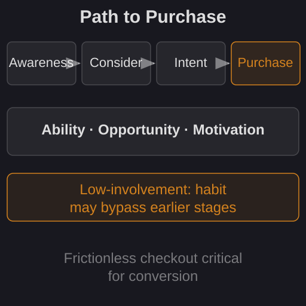

## Dual Process Theories

- `ELM and HSM: Explain information processing based on motivation and ability`
- Systematic (central route): thorough evaluation of message arguments
- Heuristic (peripheral route): simple rules like ‘experts know best’
- High involvement → central route; low involvement → peripheral
- Source attractiveness and credibility act as heuristic cues

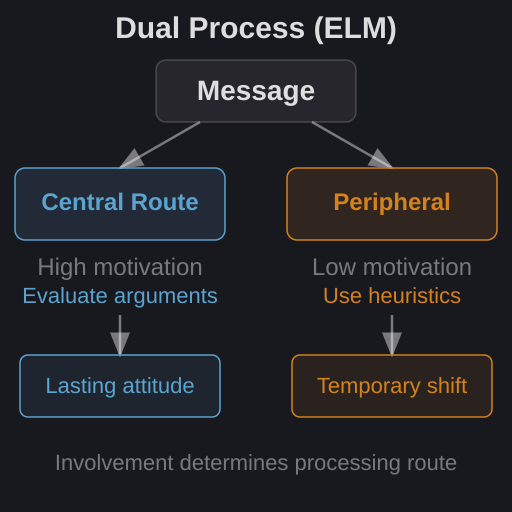

## Memory: Explicit vs. Implicit

- `Memory types: Explicit memory: conscious recollection, measured by recall & recognition`
- Implicit memory: prior exposure facilitates performance without awareness
- Priming activates concepts that influence behavior unconsciously
- Brand familiarity builds implicit preference over time
- Repeated exposure increases fluency and perceived truth

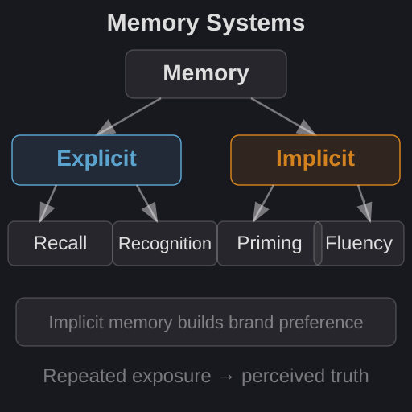

## Source Credibility

- `Trust and attraction: Credibility = expertise + trustworthiness`
- Most effective when processing motivation is low
- Source attractiveness creates a ‘halo effect’ on product evaluations
- Indirect sources: the brand itself; direct sources: spokespeople
- Celebrity mismatch with product category reduces effectiveness

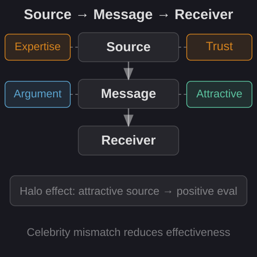

## Message Strategies

- `Argument quality: Argument quality: persuasiveness of supporting claims`
- Two-sided ads admit minor negatives to increase honesty
- Primacy effect: first arguments have strongest recall
- Recency effect: last arguments recalled better after a delay
- Strong arguments matter most under high involvement processing

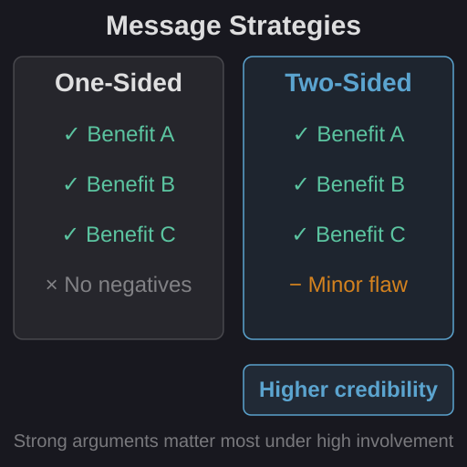

## Resistance to Persuasion

- `Reactance: Persuasion knowledge: consumer theories about advertiser motives`
- Psychological reactance: threat to freedom triggers ‘boomerang’ effect
- High-pressure tactics backfire with informed consumers
- Two-sided ads and product placement reduce resistance
- Transparency and authenticity are antidotes to reactance

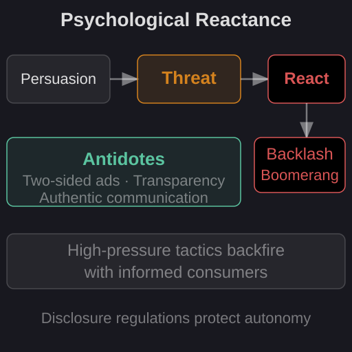

## Digital Advertising Trust

- `The Google effect: Online trust driven by ability, benevolence, and integrity beliefs`
- The ‘Google effect’: Internet used as transactive external memory
- Behavioral targeting uses past behavior to personalize ad messages
- Privacy concerns erode trust when targeting is perceived as intrusive
- Contextual advertising increasingly replaces cookie-based tracking

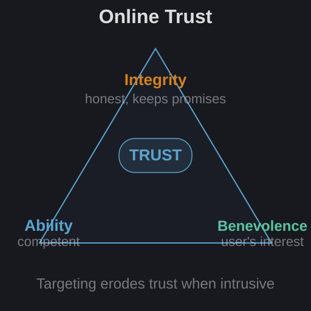

## Section 03:

Digital  
Marketing

## Analog vs. Digital Marketing

- `Push vs. pull: Analog media: push media — one-way broadcast to passive recipients`
- Digital marketing: pull media and inbound — consumers seek solutions
- Digital is a ‘lean-forward’ medium demanding control and responsiveness
- Interactivity, personalization, and real-time feedback are digital advantages
- Multichannel strategies integrate both analog and digital touchpoints

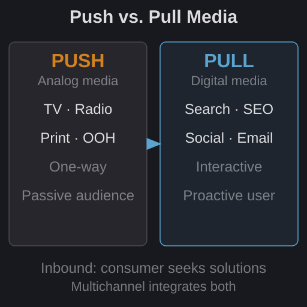

## Web 1.0: The Informational Web

- `Brochureware era: Characterized by static 'brochureware' sites with limited interaction`
- Replicated offline marketing literature in a one-to-many format
- Personal homepages: text-heavy, functioning as digital résumés
- No user-generated content; webmaster controlled all publishing
- Communication was one-directional — brand to consumer only

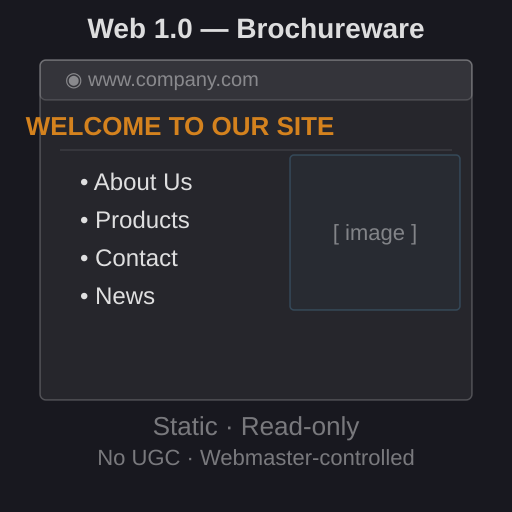

## Web 2.0: The Participatory Web

- `Social era: Defined by social networking and user-generated content`
- Consumer role shifts from passive recipient to ‘co-constructor’
- eWOM and earned media more strategically important than paid
- Platforms: YouTube, Facebook, Wikipedia, blogs, forums
- Brands must participate in conversations, not just broadcast

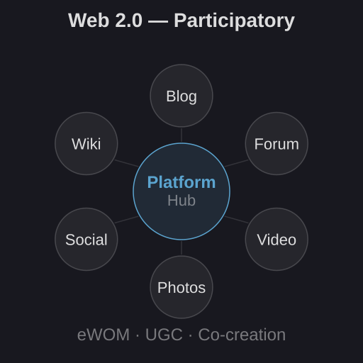

## Web 3.0: The Intelligent Web

- `AI and personalization: High levels of micro-customization across all devices`
- AI enables predictive modeling and personalized messaging
- Semantic web: machines understand context and meaning
- 5G, VR, and AR enable immersive consumer experiences
- Automated and always-on marketing at scale

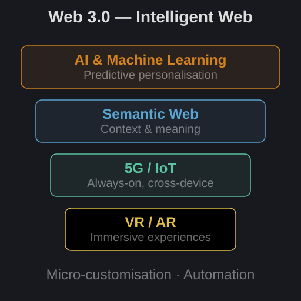

## Digital Marketing Channels

- `Six categories: Search Engine Marketing: SEO and paid search (PPC)`
- Social Media Marketing: organic and paid social campaigns
- Display Advertising: banners, video pre-rolls, programmatic
- Digital PR: influencer outreach, mentions, and editorial links
- Digital Messaging: email newsletters and mobile push notifications

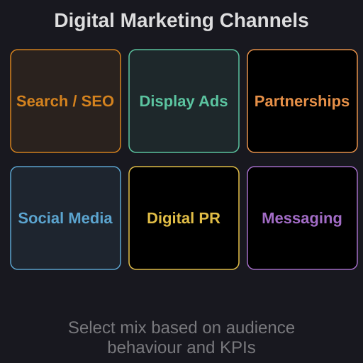

## The FAMGA Ecosystem

- `Platform dominance: FAMGA: Facebook, Amazon, Microsoft, Google, Apple`
- These platforms mediate interactions via proprietary infrastructure
- Each has unique algorithms governing search and social reach
- Data ownership by platforms limits marketer transparency
- Walled gardens require platform-specific strategies

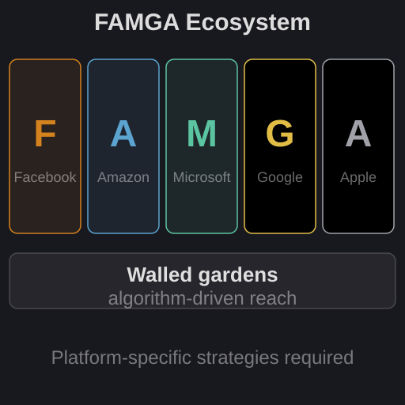

## The RACE Framework

- `Digital analytics: Reach: build awareness — impressions, traffic, social reach`
- Act: encourage site interaction — pages/visit, lead generation
- Convert: achieve sales — conversion rate, revenue, AOV
- Engage: build loyalty — NPS, repeat purchase, CLV
- Clickstream analysis maps the full visitor path to optimize conversion

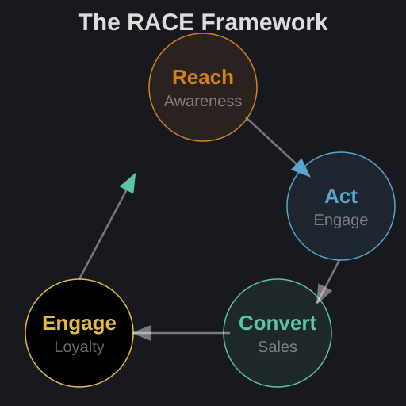

## VQVC Metrics

- `SMART objectives: Volume: unique visitors, sessions, and ad impressions`
- Quality: conversion rates, bounce rates, time on page
- Value: ROI, goal value, average order value (AOV)
- Cost: CPC, CPA, and overall media efficiency ratios
- SMART targets defined for each VQVC dimension per channel

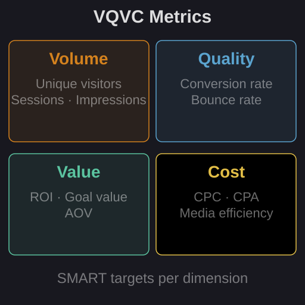

## Customer Satisfaction Online

- `Voice of the customer: Online experience: rational and emotional factors shape perceptions`
- Service-quality gap identified through VoC feedback tools
- Net Promoter Score (NPS) measures advocacy and loyalty
- Repeat purchase intention as key satisfaction indicator
- User testing and heatmaps reveal experience friction points

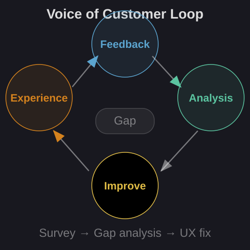

## Conversion Optimization

- `CRO and AB testing: CRO: structured experiments to improve site effectiveness`
- AB testing compares page versions to identify higher performers
- Multivariate tests assess combinations of page elements simultaneously
- Continuous cycle: diagnose → hypothesize → test → optimize
- Small CRO gains compound significantly at scale

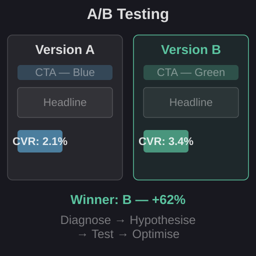

## Section 04:

SOSTAC  
Framework

## Situation Analysis

- `Digital SWOT: Audit the digital marketplace: SWOT and competitor benchmarking`
- Map competitor capabilities across the RACE framework
- Low-involvement: focus on visibility and simple triggers
- High-involvement: map complex path-to-purchase across touchpoints
- Customer persona research grounds the analysis in real behavior

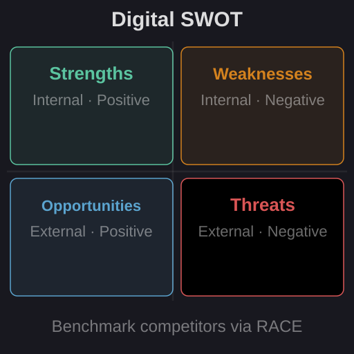

## Setting Objectives

- `SMART goals: Set numerical targets for business contribution (% online sales)`
- Define marketing outcomes: leads, engagement, brand recall
- Low-involvement: prioritize Volume (reach and frequency)
- High-involvement: prioritize Quality (leads) and Value (depth)
- Objectives must be Specific, Measurable, Achievable, Relevant, Time-bound

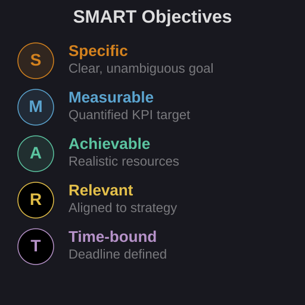